# Class activity

# Inference for logistic regression models

## Testing a single coefficient

To test a single coefficient in a logistic regression model, we typically use a *Wald test*. A Wald test leverages the fact that, if the model assumptions are satisfied, the estimated coefficients for a logistic regression model are approximately normal:

$$\widehat{\beta} \approx N(\beta, \
\mathcal{I}^{-1}(\beta))$$
Suppose we observe data $(X_1, Y_1), ..., (X_n, Y_n)$ from the following logistic regression model:

$$Y_i \sim Bernoulli(p_i)$$

$$\log \left( \frac{p_i}{1 - p_i} \right)
= \beta^T X_i$$
We have demonstrated in class that $\mathcal{I}(\beta) = X^T W X$, with $W = \text{diag}(p_i(1 - p_i))$.

The code below generates data with a single explanatory variable, fits a logistic regression model, and reports the estimated coefficients and the estimated standard errors:

```r
set.seed(11)

n <- 100
beta <- c(-1, 1)
x <- rnorm(n)
X <- cbind(1, x)
p <- c(exp(X %*% beta)/(1 + exp(X %*% beta)))

y <- rbinom(n, 1, p)

m1 <- glm(y ~ x, family = binomial)
summary(m1)$coefficients
```

```
##               Estimate Std. Error   z value     Pr(>|z|)
## (Intercept) -0.6926533  0.2286768 -3.028962 0.0024539539
## x            0.9150440  0.2735420  3.345169 0.0008223248
```

In this case, $\widehat{\beta}_1 = 0.915$, and $\widehat{SE}(\widehat{\beta}_1) = 0.274$.

Where does this estimated standard error come from? It is the square root of the second diagonal entry of $(X^T \widehat{W} X)^{-1}$, where $\widehat{W} = \text{diag}(\widehat{p}_i (1 - \widehat{p}_i))$. Note that the *estimated* probabilities are being used, because for real datasets we won’t know the true probabilities (we only know the true probabilities here because we simulated the data).

#### Question 1

The estimated inverse information matrix $(X^T \widehat{W} X)^{-1}$ can be obtained from the fitted model by `vcov(m1)` (`vcov` is short for *variance-covariance* matrix). Compute the estimate $(X^T \widehat{W} X)^{-1}$ yourself (constructing $X$ and $\widehat{W}$), and verify that `vcov(m1)` agrees with your calculations.

- Note: you can get the vector of estimated probabilities $\widehat{p}_i$ in R with

```r
m1$fitted.values
```

#### Question 2

Verify that the [2,2] entry of $(X^T \widehat{W} X)^{-1}$ is equal to $0.0748 = 0.2735^2$ (there may be some small differences due to rounding).

Now let’s verify that the distribution of $\widehat{\beta}_1$ is approximately normal, with the desired mean and variance.

#### Question 3

Using a `for` loop and the code above, simulate `nsim = 5000` different datasets in R. For each dataset, fit the logistic regression model, and store the estimated slope $\widehat{\beta}_1$. For now, use the same $X$ for each simulation (that is, do not re-sample $X$ at each iteration of the loop – only resample the response $Y$).

#### Question 4

Use a QQ plot to compare your estimated slopes $\widehat{\beta}_1$ from question 3 to a normal distribution. Does a normal distribution appear to be a good fit?

*Making a QQ plot*: here is an example of making a QQ plot to compare a sample `v` to a normal distribution:

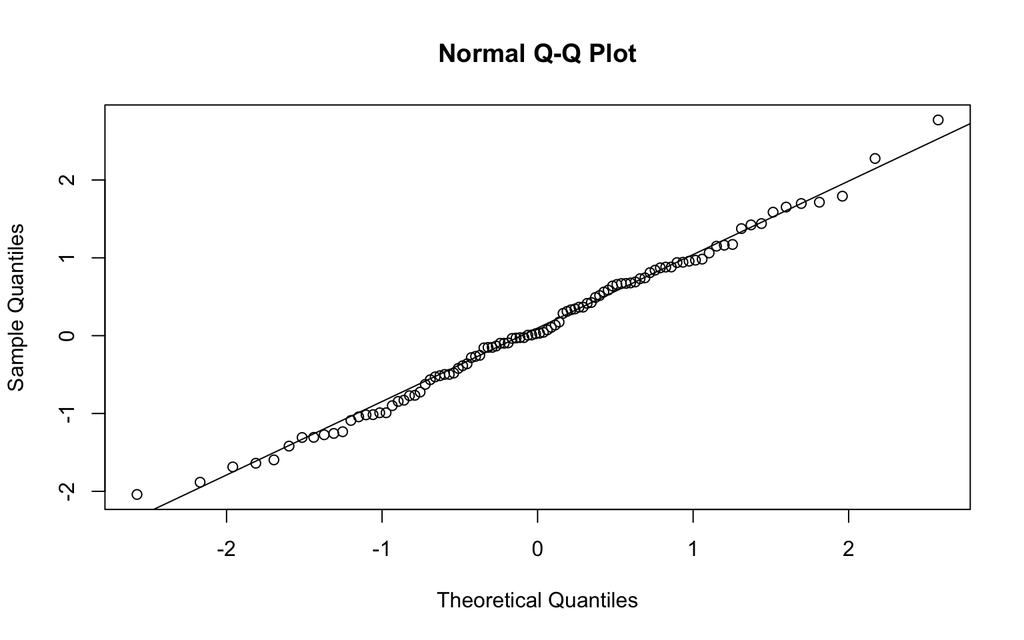

```r
v <- rnorm(100)
qqnorm(v)
qqline(v)
```

#### Question 5

Calculate the mean of your simulated slopes $\widehat{\beta}_1$ from question 3. Is the mean close to the true coefficient $\beta_1 = 1$?

$Var(\widehat{\beta}_1)$ should be approximately $[(X^T W X)^{-1}]_{2,2}$ (the [2,2] entry of the inverse Fisher information). Here, $(X^T W X)^{-1}$ uses the *true* probabilities $p_i$, rather than the estimated probabilities $\widehat{p}_i$. Because we simulated the data, we can calculate the actual Fisher information $X^T W X$, not just the estimated Fisher information $X^T \widehat{W} X$.

#### Question 6

Calculate the variance of your simulated slopes $\widehat{\beta}_1$ from question 3. Is the variance close to the theoretical value $[(X^T W X)^{-1}]_{2,2}$?

#### Question 7

Repeat questions 3–6 for different sample sizes $n$ (consider $n = 50, 100, 200$, etc.). Does the theoretical normal distribution do a better or worse job at approximating the distribution of $\widehat{\beta}_1$ when $n$ increases?

## Preview: Inference for multiple coefficients

Now, what if we want to test hypotheses about *multiple* coefficients *simultaneously*? A common method is something called a *likelihood ratio test*. We will spend a lot of time on likelihood ratio testing later in the semester; for now, we will take a sneak peek at how likelihood ratio tests behave, which will motivate our coming hypothesis testing work.

Consider the model

$$Y_i \sim Bernoulli(p_i)$$
$$\log \left( \frac{p_i}{1 - p_i} \right) = \beta_0
+ \beta_1 X_{i,1} + \beta_2 X_{i,2}$$
and suppose we want to test

$$H_0: \beta_1 = \beta_2 = 0 \hspace{1cm}
H_A: \text{at least one of } \beta_1, \beta_2 \neq 0$$

To test these hypotheses, let $L_{full}$ be the likelihood for the full model (in this case, that means both $X_{i,1}$ and $X_{i,2}$ are in the model), and let $L_{reduced}$ be the likelihood for the reduced model (in this case, that is the intercept-only model). The likelihood ratio test statistic is:

$$G = 2(\log L_{full} - \log
L_{reduced})$$

Under certain assumptions, if $H_0$ is *true* then $G \sim \chi^2_q$, where $q$ is the number of parameters we are testing. In this example, $q = 2$.

For GLMs like logistic regression, the LRT statistic is calculated through a value called the *deviance*. For logistic regression, $\text{deviance} = -2\log L$. Let’s simulate some data and fit the logistic regression model. Since we want to examine the behavior of $G$ under $H_0$, we will simulate data for which $\beta_1 = \beta_2 = 0$.

```r
set.seed(23)

n <- 100
beta <- c(-1, 0, 0)
x1 <- rnorm(n)
x2 <- rnorm(n)
X <- cbind(1, x1, x2)
p <- exp(X %*% beta)/(1 + exp(X %*% beta))
y <- rbinom(n, 1, p)

m1 <- glm(y ~ x1 + x2, family = binomial)
summary(m1)
```

```
##
## Call:
## glm(formula = y ~ x1 + x2, family = binomial)
##
## Coefficients:
##             Estimate Std. Error z value Pr(>|z|)
## (Intercept)  -1.6093     0.2723  -5.910 3.42e-09 ***
## x1            0.1388     0.2895   0.480    0.631
## x2            0.2112     0.2970   0.711    0.477
## ---
## Signif. codes:  0 '***' 0.001 '**' 0.01 '*' 0.05 '.' 0.1 ' ' 1
##
## (Dispersion parameter for binomial family taken to be 1)
##
##     Null deviance: 91.177  on 99  degrees of freedom
## Residual deviance: 90.438  on 97  degrees of freedom
## AIC: 96.438
##
## Number of Fisher Scoring iterations: 4
```

In this summary output, the *deviance* of the fitted model (called the *residual deviance* in R) is $90.438$. To test $H_0: \beta_1 = \beta_2 = 0$, we will compare $90.438$ to the deviance of the reduced model. In this example, the reduced model is the intercept-only model; and the deviance of the intercept-only model is always reported by R as the *null deviance*.

So, our test statistic is

```r
m1$null.deviance - m1$deviance
```

```
## [1] 0.7390614
```

Is this a big change? We calculate a p-value by comparing this value to a $\chi^2_2$ distribution (remember we are testing 2 coefficients).

```r
pchisq(m1$null.deviance - m1$deviance, 2, lower.tail=F)
```

```
## [1] 0.6910586
```

That’s a very large p-value! We have very little evidence against $H_0$.

#### Question 8

Repeat the code above many times, calculating the LRT statistic (`m1$null.deviance - m1$deviance`) each time. Does the $\chi^2_2$ distribution seem like a good approximation?

*Note*: one way to compare a sample to a theoretical distribution is with the empirical cdf (the estimate of the cdf from the sample). Here is an example (estimated cdf in black, true cdf in orange):

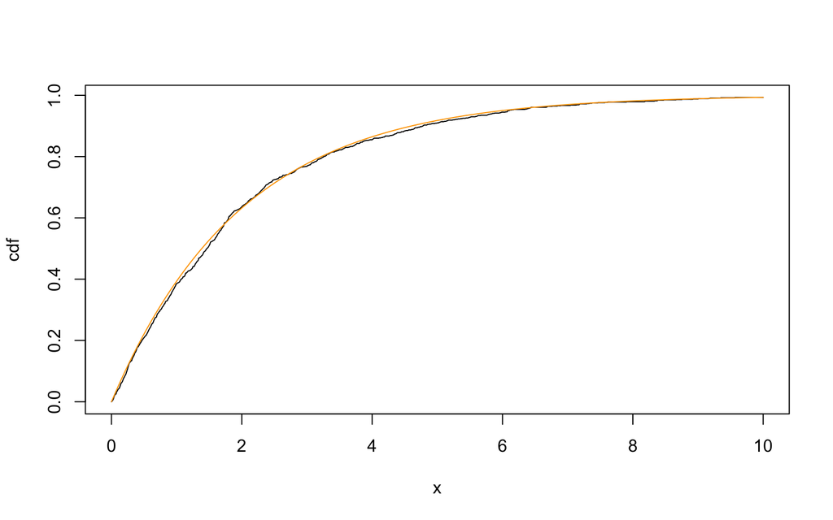

```r
v <- rchisq(1000, 2)
gridpts <- seq(0, 10, 0.01)
plot(gridpts, ecdf(v)(gridpts), type="l", xlab = "x", ylab = "cdf")
lines(gridpts, pchisq(gridpts, 2), col="orange")
```

## Inference with a random X

So far, we have kept $X$ fixed in our simulations (i.e., we have ignored the fact that really, $X$ should be random). If we account for the randomness of $X$, what do we need to change?

Well, $Var(\widehat{\beta})$ should no longer be $(X^T W X)^{-1}$, because $X$ is random! We need to consider the distribution of the observations $X_i$ too. It turns out that, if we treat the $X_i$s as random, the correct approximate variance is

$$\frac{1}{n} \mathbb{E}[p_i(1 - p_i) X_i
X_i^T]^{-1}$$
(In practice, this doesn’t really change anything, because with a single dataset our estimator of this variance is still going to be $(X^T W X)^{-1}$).

#### Question 9

Repeat question 3, but this time sample new observations $X_i$ at each iteration of the simulation, as well as new responses $Y_i$. Verify that $\widehat{\beta}_1$ still follows an approximately normal distribution.

Then, estimate $\frac{1}{n} \mathbb{E}[p_i(1 - p_i) X_i X_i^T]^{-1}$ (take many samples $X_i$ and average over them). Compare $\frac{1}{n} \mathbb{E}[p_i(1 - p_i) X_i X_i^T]^{-1}$ to the variance of $\widehat{\beta}_1$: is the theoretical variance close to the observed variance? What role does the sample size $n$ play?